# Programming with R Assignment #2b (75 points)

##### Section 2: (15 points)

##### (2) Conditional probabilities appear in many contexts and, in particular, are used by Bayes’ Theorem. Correlations are another means for evaluating dependency between variables. The dataset “faithful”” is part of the “datasets” package and may be loaded with the statement *data(faithful)*. It contains 272 observations of 2 variables; waiting time between eruptions (in minutes) and the duration of the eruption (in minutes) for the Old Faithful geyser in Yellowstone National Park.

```r
data(faithful, package = "datasets")

summary(faithful)
```

```
##    eruptions        waiting
##  Min.   :1.600   Min.   :43.0
##  1st Qu.:2.163   1st Qu.:58.0
##  Median :4.000   Median :76.0
##  Mean   :3.488   Mean   :70.9
##  3rd Qu.:4.454   3rd Qu.:82.0
##  Max.   :5.100   Max.   :96.0
```

```r
str(faithful)
```

```
## 'data.frame':    272 obs. of  2 variables:
##  $ eruptions: num  3.6 1.8 3.33 2.28 4.53 ...
##  $ waiting  : num  79 54 74 62 85 55 88 85 51 85 ...
```

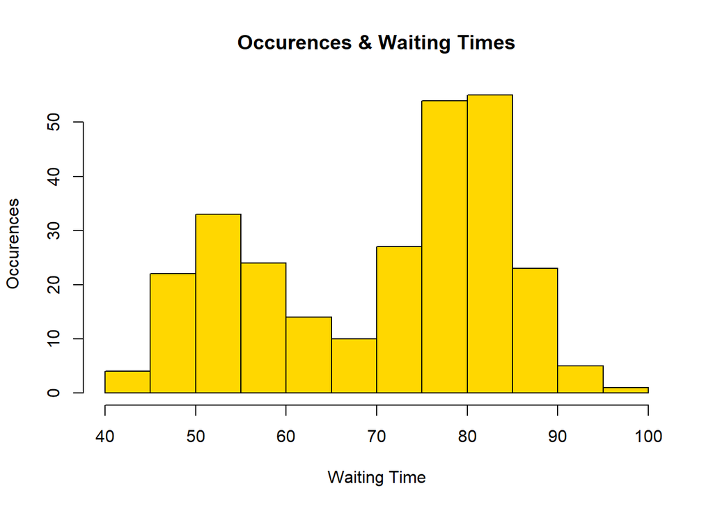

```r
hist(faithful$waiting, main = "Occurences & Waiting Times", xlab ="Waiting Time", ylab = "Occurences", col ="gold")
```

```r
w70 <- subset(faithful, waiting > 70)
e3 <- subset(w70, w70$eruptions < 3)
cond_prob <- nrow(e3)/nrow(w70)
cond_prob
```

```
## [1] 0.006060606
```

```r
w905 <- subset(faithful, faithful$waiting > 00 & faithful$eruptions < 5.0)
w905
```

```
##     eruptions waiting
## 1       3.600      79
## 2       1.800      54
## 3       3.333      74
## 4       2.283      62
## 5       4.533      85
## 6       2.883      55
## 7       4.700      88
## 8       3.600      85
## 9       1.950      51
## 10      4.350      85
## 11      1.833      54
## 12      3.917      84
## 13      4.200      78
## 14      1.750      47
```

[output cut: 254 more lines]

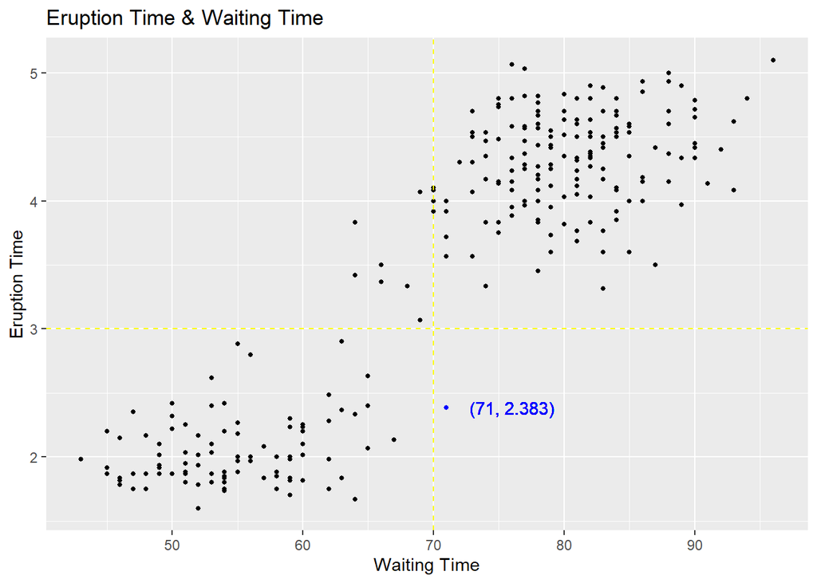

```r
ggplot(faithful, aes(x = waiting, y = eruptions)) +
  geom_point(size = 1, color="black") +
  ggtitle("Eruption Time & Waiting Time") +
  xlab("Waiting Time") +
  ylab("Eruption Time") +
  geom_hline(yintercept=3, color="yellow", linetype=2) +
  geom_vline(xintercept=70, color="yellow", linetype=2) +
  geom_point(x=71, y=2.383, size=1, color="blue") +
  geom_text(x=76, y=2.383, label="(71, 2.383)", color="blue")
```

2. What does the plot suggest about the relationship between eruption time and waiting time?

*Answer: The plot shows that as wait time increases the length of eruption also increases.*

(2)(b) (6 points) Past research indicates that the waiting times between consecutive eruptions are not independent. This problem will check to see if there is evidence of this. Form consecutive pairs of waiting times. In other words, pair the first and second waiting times, pair the third and fourth waiting times, and so forth. There are 136 resulting consecutive pairs of waiting times. Form a data frame with the first column containing the first waiting time in a pair and the second column with the second waiting time in a pair. Plot the pairs with the second member of a pair on the vertical axis and the first member on the horizontal axis.

One way to do this is to pass the vector of waiting times - faithful$waiting - to *matrix()*, specifying 2 columns for our matrix, with values organized by row; i.e. byrow = TRUE.

```r
dim(faithful)
```

```
## [1] 272   2
```

```r
colnames(faithful)
```

```
## [1] "eruptions" "waiting"
```

```r
wtime<-matrix(faithful$waiting, ncol=2, byrow="TRUE")
wtime
```

```
##        [,1] [,2]
##   [1,]   79   54
##   [2,]   74   62
##   [3,]   85   55
##   [4,]   88   85
##   [5,]   51   85
##   [6,]   54   84
##   [7,]   78   47
##   [8,]   83   52
##   [9,]   62   84
##  [10,]   52   79
##  [11,]   51   47
##  [12,]   78   69
##  [13,]   74   83
##  [14,]   55   76
```

[output cut: 122 more lines]

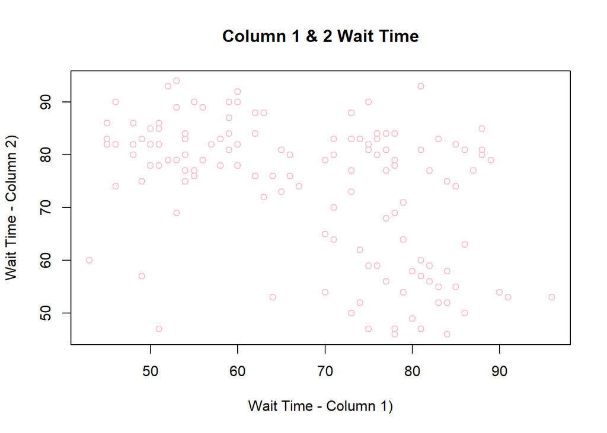

```r
plot(main="Column 1 & 2 Wait Time",y=wtime[,2],x=wtime [,1],xlab="Wait Time - Column 1)",ylab = "Wait Time - Column 2)", col="pink")
```

(2)(c) (3 points) Test the hypothesis of independence with a two-sided test at the 99% confidence level using the Kendall correlation coefficient. The *cor.test()* function can be used to structure this test and specify the appropriate - Kendall’s tau - method.

```r
cor.test(x=wtime[,1], y=wtime[,2], method="kendall")
```

```
##
##  Kendall's rank correlation tau
##
## data:  wtime[, 1] and wtime[, 2]
## z = -4.9482, p-value = 7.489e-07
## alternative hypothesis: true tau is not equal to 0
## sample estimates:
##        tau
## -0.2935579
```

##### Section 3: (15 points)

##### (3) Performing hypothesis tests using random samples is fundamental to statistical inference. The first part of this problem involves comparing two different diets. Using “ChickWeight” data available in the base R, “datasets” package, we will create a subset of the “ChickWeight” data frame. Specifically, we want to create a data frame that includes only those rows where Time == 21 AND Diet == 1 or 3.

```r
# load "ChickWeight" dataset
data(ChickWeight, package = "datasets")

# There are multiple ways to approach the subsetting task. The method you choose is up
# to you.

weightlist <- ChickWeight$Time == 21 & (ChickWeight$Diet == "1" | ChickWeight$Diet == "3")

wlist <- subset(ChickWeight[weightlist, ], select = c(weight, Time, Chick, Diet))
wlist$Diet <- factor(wlist$Diet)
str(wlist)
```

```
## Classes 'nfnGroupedData', 'nfGroupedData', 'groupedData' and 'data.frame':   26 obs. of  4 variables:
##  $ weight: num  205 215 202 157 223 157 305 98 124 175 ...
##  $ Time  : num  21 21 21 21 21 21 21 21 21 21 ...
##  $ Chick : Ord.factor w/ 50 levels "18"<"16"<"15"<..: 15 17 14 11 18 12 20 5 7 13 ...
##  $ Diet  : Factor w/ 2 levels "1","3": 1 1 1 1 1 1 1 1 1 1 ...
```

```r
head(wlist)
```

```
##    weight Time Chick Diet
## 12    205   21     1    1
## 24    215   21     2    1
## 36    202   21     3    1
## 48    157   21     4    1
## 60    223   21     5    1
## 72    157   21     6    1
```

```r
# The values in your subsetted data frame should match those below:
# > head(df)
#    weight Time Chick Diet
# 12    205   21     1    1
# 24    215   21     2    1
# 36    202   21     3    1
# 48    157   21     4    1
# 60    223   21     5    1
# 72    157   21     6    1
```

##### The data frame, “result”, has chick weights for two diets, identified as diet “1” and “3”. Use the data frame, “result,” to complete the following item.

(3)(a) (3 points) Display two side-by-side vertical boxplots using par(mfrow = c(1,2)). One boxplot would display Diet “1” and the other Diet “3”.

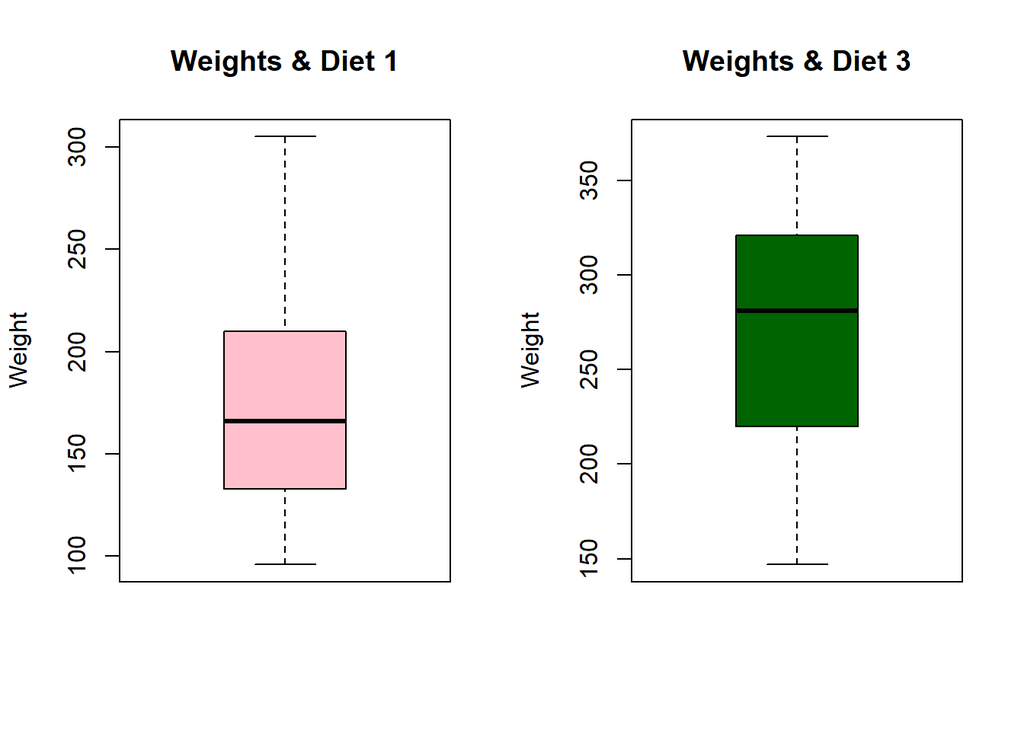

```r
par(mfrow = c(1,2))
bxp1 <- subset(wlist, Diet==1)
bxp2 <- subset(wlist, Diet==3)
boxplot(bxp1$weight, main="Weights & Diet 1", ylab="Weight", col="pink")
boxplot(bxp2$weight, main="Weights & Diet 3", ylab="Weight", col="darkgreen")
```

```r
t.test(bxp1$weight, bxp2$weight, conf= 0.95, alternative="two.sided", var.equal= TRUE)
```

```
##
##  Two Sample t-test
##
## data:  bxp1$weight and bxp2$weight
## t = -3.5955, df = 24, p-value = 0.001454
## alternative hypothesis: true difference in means is not equal to 0
## 95 percent confidence interval:
##  -145.67581  -39.42419
## sample estimates:
## mean of x mean of y
##    177.75    270.30
```

##### Working with paired data is another common statistical activity. The “ChickWeight” data will be used to illustrate how the weight gain from day 20 to 21 may be analyzed. This time, we will look only at those individuals on Diet == “3”. You will need to add code below creating two (2) vectors. One (1) vector should include all the Time == 20 weights of those individuals on Diet == “3”; a second should include all the Time == 21 weights of those individuals on Diet == “3”.

```r
# There are multiple ways to approach the subsetting task. The method you choose is up
# to you.

data(ChickWeight)
dwlist <- ChickWeight$Diet == "3"
before <- subset(ChickWeight[dwlist,], Time == 20, select =weight)$weight
after <- subset(ChickWeight[dwlist,], Time == 21, select =weight)$weight
cbind(before,after)
```

```
##       before after
##  [1,]    235   256
##  [2,]    291   305
##  [3,]    156   147
##  [4,]    327   341
##  [5,]    361   373
##  [6,]    225   220
##  [7,]    169   178
##  [8,]    280   290
##  [9,]    250   272
## [10,]    295   321
```

```r
# The first six (6) elements of your Time == 20 vector should match those below:
# [1] 235 291 156 327 361 225
```

(3)(c) (3 points) Present a scatterplot of the Time == 21 weights as a function of the Time == 20 weights. Include a diagonal line with zero intercept and slope equal to one. Title and label the variables in this scatterplot.

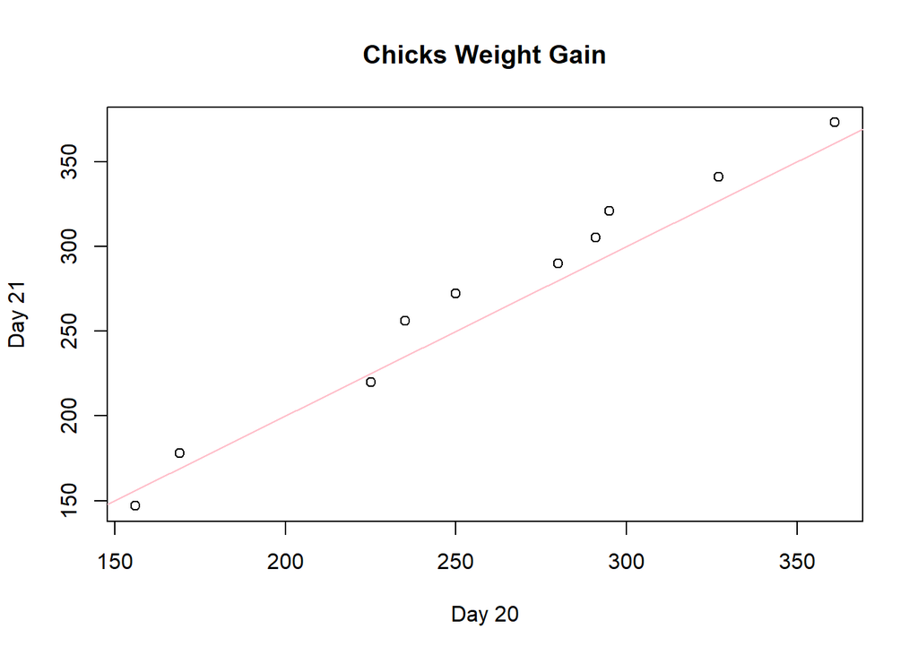

```r
plot(before,after, main= "Chicks Weight Gain", xlab="Day 20", ylab="Day 21")
abline(a=0, b=1, h=NULL, V=NULL, reg=NULL, col="pink")
```

(3)(d) (6 points) Calculate and present a one-sided, 95% confidence interval for the average weight gain from day 20 to day 21. Write the code for the paired t-test and for determination of the confidence interval endpoints. **Do not use *t.test()**, although you may check your answers using this function. Present the resulting test statistic value, critical value, p-value and confidence interval.

```r
wg <- after-before
n <- length(wg)
df <- n-1
sd <- sd(wg)
mean <- mean(wg)

tstat <- (mean-0)/(sd/sqrt(n))
cat("Test Statistic Value: ", tstat, "\n")
```

```
## Test Statistic Value:  3.225267
```

```r
cval <- qt(0.95, df)
cat("Critical Value: ", cval, "\n")
```

```
## Critical Value:  1.833113
```

```r
pval <- pt(tstat, df, lower = FALSE)
cat("P-Value: ", pval, "\n")
```

```
## P-Value:  0.00520061
```

```r
cinv <- cval*(sd/sqrt(n))
con <- mean-cinv
cat("One-Sided Confidence Interval: (", con, ", oo)\n")
```

```
## One-Sided Confidence Interval: ( 4.920696 , oo)
```

##### Section 4: (15 points)

##### (4) Statistical inference depends on using a sampling distribution for a statistic in order to make confidence statements about unknown population parameters. The Central Limit Theorem is used to justify use of the normal distribution as a sampling distribution for statistical inference. Using Nile River flow data from 1871 to 1970, this problem demonstrates sampling distribution convergence to normality. Use the code below to prepare the data. Refer to this example when completing (4)(c) below.

```r
data(Nile, package = "datasets")

data(Nile, package = "datasets")
summary(Nile)
```

```
##    Min. 1st Qu.  Median    Mean 3rd Qu.    Max.
##   456.0   798.5   893.5   919.4  1032.5  1370.0
```

(4)(a) (3 points) Using Nile River flow data and the “moments” package, calculate skewness and kurtosis. Present a QQ plot and boxplot of the flow data side-by-side using *qqnorm()*, *qqline()* and *boxplot()*; *par(mfrow = c(1, 2))* may be used to locate the plots side-by-side. Add features to these displays as you choose.

```r
library(moments)
skewness(Nile)
```

```
## [1] 0.3223697
```

```r
kurtosis(Nile)
```

```
## [1] 2.695093
```

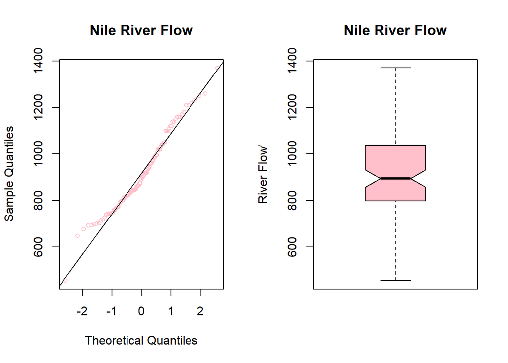

```r
par(mfrow = c(1, 2))
qqnorm(Nile, col="pink", main="Nile River Flow", cex=.75)
qqline(Nile)
boxplot(Nile, horizontal=FALSE, notch=TRUE, col="pink", main="Nile River Flow", ylab="River Flow'")
```

```r
set.seed(124)
sample1 <- rep(1:1000,0)
sample2 <- rep(1:1000,0)

for(i in 1:1000){
  sample1[i] <- mean(sample(Nile, 16, replace=TRUE), na.rm=TRUE)
}

set.seed(127)
for(i in 1:1000){
  sample2[i] <- mean(sample(Nile, 64, replace=TRUE), na.rm=TRUE)
}

means <- c(mean(sample1), mean(sample2))
sds <- c(sd(sample1), sd(sample2))
vars <- c(var(sample1), var(sample2))

samp_sum <- cbind(means, sds, vars)
colnames(samp_sum) <- c("Mean", "Standard Deviation", "Variance")
rownames(samp_sum) <- c("sample1", "sample2")
samp_sum
```

```
##             Mean Standard Deviation  Variance
## sample1 918.7364           42.00156 1764.1312
## sample2 918.5149           20.22883  409.2054
```

(4)(c) (6 points) Present side-by-side histograms of “sample1” and “sample2” with the normal density curve superimposed. To prepare comparable histograms, it will be necessary to use “freq = FALSE” and to maintain the same x-axis with “xlim = c(750, 1050)”, and the same y-axis with “ylim = c(0, 0.025).” **To superimpose separate density functions, you will need to use the mean and standard deviation for each “sample” - each histogram - separately.**

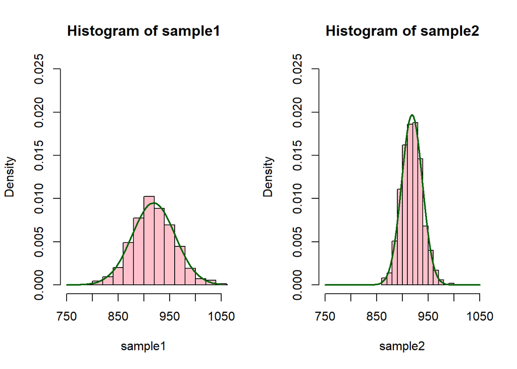

```r
# Create histograms of "sample1" and "sample2" with normal density curves superimposed

par(mfrow = c(1, 2))
hist(sample1, freq=FALSE, xlim=c(750, 1050), ylim=c(0,0.025), col="pink")
curve(dnorm(x, mean = mean(sample1), sd = sd(sample1)), col = "darkgreen", lwd = 2, add = TRUE)
hist(sample2, freq=FALSE, xlim=c(750, 1050), ylim=c(0,0.025), col="pink")
curve(dnorm(x, mean = mean(sample2), sd = sd(sample2)), col = "darkgreen", lwd = 2, add = TRUE)
```

##### Section 5: (15 points)

##### (5) This problem deals with contingency table analysis. This is an example of categorical data analysis (see Kabacoff, pp. 145-151). The “warpbreaks” dataset gives the number of warp breaks per loom, where a loom corresponds to a fixed length of yarn. There are 54 observations on 3 variables: breaks (numeric, the number of breaks), wool (factor, type of wool: A or B), and tension (factor, low L, medium M and high H). These data have been studied and used for example elsewhere. For the purposes of this problem, we will focus on the relationship between breaks and tension using contingency table analysis.

(5)(a)(5 points) warpbreaks is part of the “datasets” package and may be loaded via *data(warpbreaks)*. Load “warpbreaks” and present the structure using *str()*. Calculate the median number of breaks for the entire dataset, disregarding “tension” and “wool”. Define this median value as “median_breaks”. Present a histogram of the number of breaks with the location of the median indicated.

```r
data(warpbreaks, package = "datasets")
data(warpbreaks, package = "datasets")
str(warpbreaks)
```

```
## 'data.frame':    54 obs. of  3 variables:
##  $ breaks : num  26 30 54 25 70 52 51 26 67 18 ...
##  $ wool   : Factor w/ 2 levels "A","B": 1 1 1 1 1 1 1 1 1 1 ...
##  $ tension: Factor w/ 3 levels "L","M","H": 1 1 1 1 1 1 1 1 1 2 ...
```

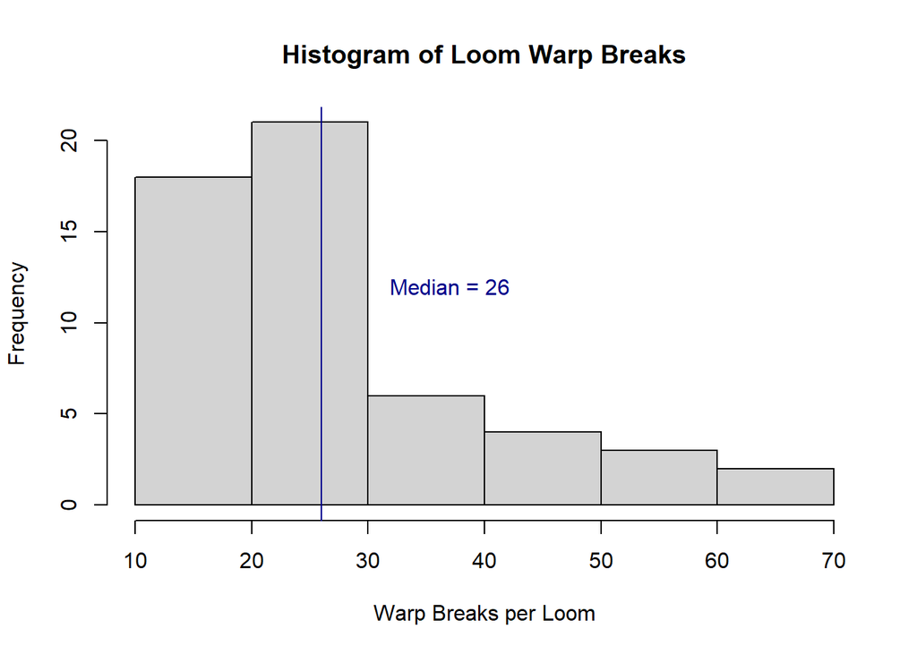

```r
mb <- median(warpbreaks$breaks)
hist(warpbreaks$breaks, main="Histogram of Loom Warp Breaks", xlab="Warp Breaks per Loom")
abline(v = mb, col = "darkblue")
text(x=37, y=12,"Median = 26", col="darkblue")
```

```r
med <- factor(ifelse(warpbreaks$breaks < mb, "below", "above"))
warpbreaks <- cbind(warpbreaks, med)
summary(warpbreaks)
```

```
##      breaks      wool   tension    med
##  Min.   :10.00   A:27   L:18    above:29
##  1st Qu.:18.25   B:27   M:18    below:25
##  Median :26.00          H:18
##  Mean   :28.15
##  3rd Qu.:34.00
##  Max.   :70.00
```

```r
hh <- table(warpbreaks$tension, warpbreaks$med)
hh
```

```
##
##     above below
##   L    14     4
##   M    10     8
##   H     5    13
```

(5)(b)(3 points) Using the table constructed in (5)(a), test at the 5% level the null hypothesis of independence using the uncorrected *chisq.test()* (Black, Business Statistics, Section 16.2). Show the results of this test and state your conclusions.

```r
chisq.test(hh, correct=FALSE)
```

```
##
##  Pearson's Chi-squared test
##
## data:  hh
## X-squared = 9.0869, df = 2, p-value = 0.01064
```

```r
#Null hypothesis must be rejected. Variables are not independent.
```

(5)(c) (3 points) ‘Manually’ calculate the chi-squared statistic and p-value of the table from (5)(a). The *addmargins()* function can be used to add row and column sums to the table; useful for calculating the expected values for each cell. You should be able to match the chi-squared and p-values from (5)(b). The underlying code for the *chisq.test()* function can be viewed by entering *chisq.test* - without parentheses - in the Console. You are given code below to create the table, add row and column sums and calculate the expected values for the for the first of two (2) rows. You will need to add code to calculate the expected values for the second row and the chi-squared. The *pchisq()* function can be used to return the p-value.

```r
totals <- table(warpbreaks$tension, warpbreaks$med)
mar_tbl <- addmargins(totals)

e11 <- mar_tbl[4, 1] * mar_tbl[1, 3] / mar_tbl[4, 3]
e12 <- mar_tbl[4, 2] * mar_tbl[1, 3] / mar_tbl[4, 3]
e21 <- mar_tbl[4, 1] * mar_tbl[2, 3] / mar_tbl[4, 3]
e22 <- mar_tbl[4, 2] * mar_tbl[2, 3] / mar_tbl[4, 3]
e31 <- mar_tbl[4, 1] * mar_tbl[3, 3] / mar_tbl[4, 3]
e32 <- mar_tbl[4, 2] * mar_tbl[3, 3] / mar_tbl[4, 3]

chi_sq_stat <- ((mar_tbl[1,1]-e11)^2/e11) + ((mar_tbl[1,2]-e12)^2/e12) + ((mar_tbl[2,1]-e21)^2/e21) + ((mar_tbl[2,2]-e22)^2/e22) + ((mar_tbl[3,1]-e31)^2/e31) + ((mar_tbl[3,2]-e32)^2/e32)
cat("Chi-squared statistic: ",chi_sq_stat,"\n")
```

```
## Chi-squared statistic:  9.086897
```

```r
p_val <- pchisq(chi_sq_stat, 2, lower.tail=FALSE)
cat("P-value: ", p_val)
```

```
## P-value:  0.01063667
```

(5)(d) (4 points) Build a user-defined function, using your code for (5)(c).We want to pass our (5)(a) table to our function and have it return the chi-squared statistic and p-value. You’re provided with the ‘shell’ of a function and will need to add code to calculate the expected values, the chi-squared statistic, the p-value and return (i.e. output) the chi-squared and p-value.

```r
chisstat_function <- function(x) {
  # Code for calculating the expected values
  e11 <- mar_tbl[4, 1] * mar_tbl[1, 3] / mar_tbl[4, 3]
  e12 <- mar_tbl[4, 2] * mar_tbl[1, 3] / mar_tbl[4, 3]
  e21 <- mar_tbl[4, 1] * mar_tbl[2, 3] / mar_tbl[4, 3]
  e22 <- mar_tbl[4, 2] * mar_tbl[2, 3] / mar_tbl[4, 3]
  e31 <- mar_tbl[4, 1] * mar_tbl[3, 3] / mar_tbl[4, 3]
  e32 <- mar_tbl[4, 2] * mar_tbl[3, 3] / mar_tbl[4, 3]

  # Code for calculating the chi-squared
  chiSq <- ((x[1,1]-e11)^2/e11) + ((x[1,2]-e12)^2/e12) + ((x[2,1]-e21)^2/e21) + ((x[2,2]-e22)^2/e22) + ((x[3,1]-e31)^2/e31) + ((x[3,2]-e32)^2/e32)

  # Code for calculating the degrees of freedom and p-value
  df <- nrow(x)-1
  p_val <- pchisq(chiSq, df, lower.tail=FALSE)

  # Code to output the chi-squared, degrees of freedom and p-value
  return(list("chi-squared" = chiSq,
              "degrees of freedom" = df,
              "p-value" = p_val))
}
x<-addmargins(totals)
 chisstat_function(x)
```

```
## $`chi-squared`
## [1] 9.086897
##
## $`degrees of freedom`
## [1] 3
##
## $`p-value`
## [1] 0.02815758
```

```r
# Below is a function that should return the same values as chisq.test() and your
# function from (5)(d). Here, though, the function loops over the rows and columns
# to calculate the expected values. Ideally, this function would work for any sized
# table.

chisqfun <- function(t) {
   x <- addmargins(t)
   e <- matrix(0, nrow = nrow(t), ncol = ncol(t), byrow = T)
   r <- matrix(0, nrow = nrow(t), ncol = ncol(t), byrow = T)
   for (i in 1:dim(t)[1]) {
       for (j in 1:dim(t)[2]) {
          e[i,j] = x[nrow(x),j] * x[i,ncol(x)]/x[nrow(x), ncol(x)]
         r[i,j] = ((x[i,j] - e[i,j])^2)/e[i,j]
         }
     }
  chi <- sum(r)
  xdf <- (nrow(t) - 1) * (ncol(t) - 1)
  pv <- pchisq(chi, df = xdf, lower.tail = FALSE)
  return(list("chi-squared" = chi, "degrees_of_freedom" = xdf, "p-value" = pv))
  }
```